# **Insider Trades and Stock Performance**

There are many reasons why insiders trade their company stock and It's not correct to assume it's because of a particularly bad/good forecast for a company's earnings or some other reason tied to the underlying value of their company. However, there might be some loose association for trades of particular kinds. For example, around half the trades that are reported from Google are a result of direct sales of stock, not option exercise which is often necessary to do because those expire anyway. Sales that aren't option exercises aren't necessary so they might be for any number of reasons, one could be a belief that the value of keeping shares has in some way diminished.

In this project, I set out to accomplish a few goals. The first is to extract insider trading data for a company, Google as a first example, fit the data into a dataframe and explore the relationship between the insider trade type, trader, trade date and the actual performance of the stock itself. I can then compare the performance of traders at different companies.

I will mainly focus on stock sales and not option exercises or stock purchases to simplify the analysis and because option exercises are mostly tied to a date and not indicative of intent and share purchases are rarely reported in my data.

```python
import pandas as pd
import requests
import matplotlib.pyplot as plt
from bs4 import BeautifulSoup
import numpy as np
np.warnings.filterwarnings('ignore', category=np.VisibleDeprecationWarning)
import matplotlib.dates as mdates
from decimal import Decimal
from re import sub
from dateutil.relativedelta import relativedelta
import yfinance as yf
import numpy as np
from sklearn.linear_model import LinearRegression
import statsmodels.api as sm
import statsmodels.formula.api as smf
```

**Data Extraction**

There are many ways to get insider trading data, either directly from the SEC website or through EDGAR API. One shortcoming of the SEC website is that it requires the CIK identifier for a public company to access the website its trades are reported in. This isn't too much of a hassle, since the CIK is publicly known, but it is annoying to deal with. The bigger issue it there is often a reliability problem when doing an automated scraping of the website since the sec, for good reason doesn't want to overwhelm their servers with requests from bots.

Another option is the Edgar API which is provided by the SEC and has a good request limit of ~10 a second. But the data is returned as JSON which can be decoded into a dataframe, however, there were some issues that I had with this method. Certain columns would be missing or data wasn't read into frames the way I had thought it should.

The final option is to scrape from a third-party site. I chose [open insider](http://openinsider.com/) because it made querying for range effortless and had all the data on trades that I wanted in a table format.

```python
ticker = 'GOOG'
def get_page(ticker):
  url = f"http://openinsider.com/screener?s={ticker}&o=&pl=&ph=&ll=&lh=&fd=730&fdr=&td=0&tdr=&fdlyl=&fdlyh=&daysago=&xp=1&xs=1&vl=&vh=&ocl=&och=&sic1=-1&sicl=100&sich=9999&grp=0&nfl=&nfh=&nil=&nih=&nol=&noh=&v2l=&v2h=&oc2l=&oc2h=&sortcol=0&cnt=300&page=1"
  headers = {'User-agent' : 'Mozilla/5.0 (Windows; U; Windows NT 5.1; de; rv:1.9.1.5) Gecko/20091102 Firefox/3.5.5'}
  page = requests.get(url, headers=headers,  allow_redirects=True)
  return page
page = get_page(ticker)
```

**Data Parsing**

I had an issue with reading the web page directly into a table using pandas because the read-in frame had wrong column names and some data was not read from the table at all. Instead, I decided to find the table rows and build an array for that row using the td tags as values. Then I added this array to a 'cells' array which was my dataframe in a 2d array format. Pandas was able to decode this into a dataframe very easily.

```python
"""
This method will take a response object
and extract the contents of the first
table it finds into a dataframe and then return that
dataframe.
"""
def get_cells(page):
  soup = BeautifulSoup(page.text)
  table = soup.find('table', {'class':'tinytable'})
  header = table.find('thead')
  headers = [th.text.replace(u'\xa0', u'') for th in header.find_all('th')]
  rows = table.find_all('tr')
  cells = []

  for row  in rows:
    lst = row.find_all('td')
    if lst :
      cells.append([td.text for td in lst])
  return (headers, cells)
```

[output not shown]

**Data Management**

After I had the data available in a dataframe I had to manage the data so that it was in the right format. For quantity sold and price, I had to remove the commas to convert the columns to numeric values. I also noticed that quantity was negative if the trade was a sale of shares so I created a new column with the absolute value of the quantity sold and another column using the proportion of the quantity sold for each trade relative to all the quantities sold. The second new column makes it easier to plot the quantity data. I also added a color column for when it comes to plot the trade as a sale/option exercise/buy.

```python
headers, cells = get_cells(page)
df = pd.DataFrame(cells)
df.columns = headers

"""
This method is applied to
each row of the dataframe
and sets a color column based
on the trade type.
"""
def get_color(x):
  trade_type = x['TradeType']
  if('Sale' in trade_type):
    if('OE' in trade_type):
      return 'orange'
    else:
      return 'red'
  else:
    if('OE' in trade_type):
      return 'orange'
    else:
      return 'green'
"""
This method cleans up the
dataframe columns so that they use
numeric values where appropriate
and adds useful columns for graphing
quantity
"""
def format_df(df):
  df['Qty'] = pd.to_numeric(df['Qty'].str.strip().str.replace(",", ""))
  df['TradeDate'] =pd.to_datetime(df['TradeDate'])
  df['Color'] = df.apply(get_color , axis=1)
  df['AbsQty'] = df['Qty'].abs()
  totalQty = df['AbsQty'].sum()
  df['AbsQty8k'] = df.apply(lambda x : (x['AbsQty']/totalQty)*8000, axis=1)
  df['Price'] = df.apply(lambda x: Decimal(sub(r'[^\d.]', '', x['Price'])), axis=1)
  return df
df = format_df(df)



df.head()
```

|  | X | FilingDate | TradeDate | Ticker | InsiderName | Title | TradeType | Price | Qty | Owned | ΔOwn | Value | 1d | 1w | 1m | 6m | Color | AbsQty | AbsQty8k |
| --- | --- | --- | --- | --- | --- | --- | --- | --- | --- | --- | --- | --- | --- | --- | --- | --- | --- | --- | --- |
| 0 |  | 2022-12-01 19:43:08 | 2022-12-01 | GOOG | O'Toole Amie Thuener | VP, Chief Accounting Officer | S - Sale | 101.13 | -855 | 55,028 | -2% | -$86,467 |  |  |  |  | red | 855 | 2.958851 |
| 1 |  | 2022-11-28 19:59:56 | 2022-11-25 | GOOG | Mather Ann | Dir | S - Sale | 98.48 | -360 | 35,540 | -1% | -$35,453 |  |  |  |  | red | 360 | 1.245832 |
| 2 |  | 2022-11-03 17:49:11 | 2022-11-03 | GOOG | Mather Ann | Dir | S - Sale | 86.31 | -260 | 35,900 | -1% | -$22,441 |  |  |  |  | red | 260 | 0.899768 |
| 3 |  | 2022-11-03 17:29:11 | 2022-11-02 | GOOG | O'Toole Amie Thuener | VP, Chief Accounting Officer | S - Sale | 90.85 | -855 | 56,934 | -1% | -$77,677 |  |  |  |  | red | 855 | 2.958851 |
| 4 |  | 2022-10-25 18:41:04 | 2022-10-25 | GOOG | Mather Ann | Dir | S - Sale | 103.23 | -280 | 36,160 | -1% | -$28,904 |  |  |  |  | red | 280 | 0.968981 |

**Data Management**

One problem with the data from the SEC is that the prices aren't adjusted based on splits that happen after the trade. This is a problem that the open insider website keeps which means I will have to get all the previous stock splits that happened in the date range and apply the necessary adjustments.

```python
#prices for goog were well above 2300 before the 20 to 1 split earlier this year
print(df['Price'])
```

```
0       101.13
1        98.48
2        86.31
3        90.85
4       103.23
        ...
295    2357.28
296    2405.72
297    2400.00
298    2361.59
299    2369.74
Name: Price, Length: 300, dtype: object
```

```python
"""
This method takes the splits a
stock has done and applies them to
legacy stock values that need to
be updated
"""
def adj_split(x, splits):
  split_adj = 1
  trade_date = x["TradeDate"]
  for idx in splits.index:
    if(trade_date < idx.tz_localize(None)):
      split_adj *= splits[idx]
  return split_adj

goog = yf.Ticker("GOOG")
splits = goog.splits
df['AdjPrice'] = df.apply(lambda x: float(x['Price'])/adj_split(x, splits), axis = 1)
```

```python
#This data is now correct to the value of the stock currently.
print(df['AdjPrice'])
```

```
0      101.1300
1       98.4800
2       86.3100
3       90.8500
4      103.2300
         ...
295    117.8640
296    120.2860
297    120.0000
298    118.0795
299    118.4870
Name: AdjPrice, Length: 300, dtype: float64
```

**Data Extraction**

I had to extract the stock value for the range of dates I had trade data for to see what changed after a stock sale. This was achieved using the yfinance package which returned a dataframe of stock data I needed. It was formatted correctly so I didn't need to wrangle the data.

```python
"""
This metod returns the stock
values in the range of dates passed
for a given ticker.
"""
def get_df_stock(dates, ticker):
  start_date = dates[0]
  end_date = dates[-1] + relativedelta(months=+4)
  data = yf.download(ticker, start_date, end_date)
  df_stock = pd.DataFrame(data)
  return df_stock
dates = list(df['TradeDate'])
dates.sort()
df_stock = get_df_stock(dates, ticker)
df_stock.head()
```

```
[*********************100%***********************]  1 of 1 completed
```

| Date | Open | High | Low | Close | Adj Close | Volume |
| --- | --- | --- | --- | --- | --- | --- |
| 2021-05-04 | 118.487000 | 118.962997 | 115.584999 | 117.712502 | 117.712502 | 35120000 |
| 2021-05-05 | 118.420998 | 119.110001 | 117.570503 | 117.836998 | 117.836998 | 21806000 |
| 2021-05-06 | 117.531998 | 119.135498 | 117.116898 | 119.067497 | 119.067497 | 20618000 |
| 2021-05-07 | 120.000000 | 120.820503 | 119.500000 | 119.934502 | 119.934502 | 23272000 |
| 2021-05-10 | 118.744499 | 118.900002 | 116.736504 | 117.083000 | 117.083000 | 26006000 |

**Exploratory Data Analysis**

Since the goal of this project is to look at trades that may have something to do with the outlook of a company from an insider perspective, I can ignore trades that are option exercises because those had to eventually happen or they would expire.

```python
df_no_OE = df.drop(df[df['Color'] == 'orange'].index)
df_no_OE.head()
```

|  | X | FilingDate | TradeDate | Ticker | InsiderName | Title | TradeType | Price | Qty | Owned | ΔOwn | Value | 1d | 1w | 1m | 6m | Color | AbsQty | AbsQty8k | AdjPrice |
| --- | --- | --- | --- | --- | --- | --- | --- | --- | --- | --- | --- | --- | --- | --- | --- | --- | --- | --- | --- | --- |
| 0 |  | 2022-12-01 19:43:08 | 2022-12-01 | GOOG | O'Toole Amie Thuener | VP, Chief Accounting Officer | S - Sale | 101.13 | -855 | 55,028 | -2% | -$86,467 |  |  |  |  | red | 855 | 2.958851 | 101.13 |
| 1 |  | 2022-11-28 19:59:56 | 2022-11-25 | GOOG | Mather Ann | Dir | S - Sale | 98.48 | -360 | 35,540 | -1% | -$35,453 |  |  |  |  | red | 360 | 1.245832 | 98.48 |
| 2 |  | 2022-11-03 17:49:11 | 2022-11-03 | GOOG | Mather Ann | Dir | S - Sale | 86.31 | -260 | 35,900 | -1% | -$22,441 |  |  |  |  | red | 260 | 0.899768 | 86.31 |
| 3 |  | 2022-11-03 17:29:11 | 2022-11-02 | GOOG | O'Toole Amie Thuener | VP, Chief Accounting Officer | S - Sale | 90.85 | -855 | 56,934 | -1% | -$77,677 |  |  |  |  | red | 855 | 2.958851 | 90.85 |
| 4 |  | 2022-10-25 18:41:04 | 2022-10-25 | GOOG | Mather Ann | Dir | S - Sale | 103.23 | -280 | 36,160 | -1% | -$28,904 |  |  |  |  | red | 280 | 0.968981 | 103.23 |

**Exploratory Data Analysis**

Looking at the results almost all insider trades are the selling of shares. Amount the sold shares there is an even split between the shares sold that were option exercises or sales. It appears that the option exercises are very regular and consistent in size which makes sense since they are defined by a contract. The sales are often inconsistent and their sizes change dramatically between insider and date.

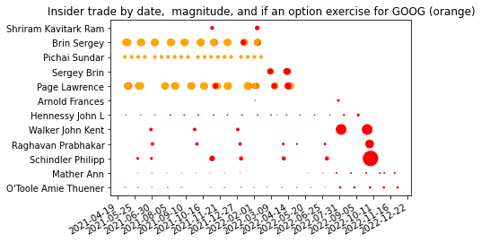

```python
plt.gca().xaxis.set_major_formatter(mdates.DateFormatter('%Y-%m-%d'))
plt.gca().xaxis.set_major_locator(mdates.DayLocator(interval=36))

scatter = plt.scatter(x=df['TradeDate'], y=df['InsiderName'], s=df['AbsQty8k'], c=df['Color'])
plt.title(label="Insider trade by date,  magnitude, and if an option exercise for GOOG (orange)")
plt.gcf().autofmt_xdate()
plt.show()
```

**Exploratory Data Analysis**

Looking at the share of trades by the number of shares traded most are unsurprisingly by the founder of Google Sergey Brin and Lawrence Page. Most other insiders have a lot fewer shares traded likely because of the high entry cost for goog before the 20 to 1 split.

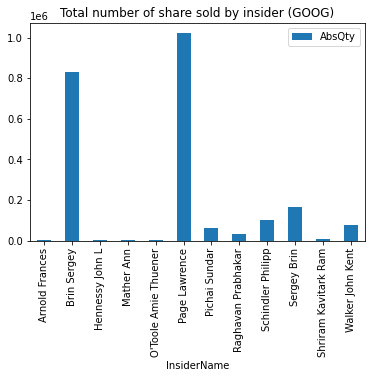

```python
df_groupedIN = df.groupby(['InsiderName']).agg(
    TradeType = ('TradeType', 'max'),
    TradeDate = ('TradeDate', 'max'),
    InsiderName = ('InsiderName', 'max'),
    AbsQty = ('AbsQty', 'sum')
)

_ = df_groupedIN.plot.bar(x='InsiderName', y='AbsQty', title="Total number of share sold by insider (GOOG)")
```

**Exploratory Data Analysis**

Now looking at just sales and viewing them superimposed on the stock value for GOOG we can begin to see if a trade was ill-timed or if it was beneficial in the long run. From a cursory look at the sales, it appears that many happened before the large bear run in early 2022. Some happened during a trench in the data which indicates mixed results for insider trades. There also appears to be one data point that isn't connected to the stock value but it was likely a data source error so I ignored it.

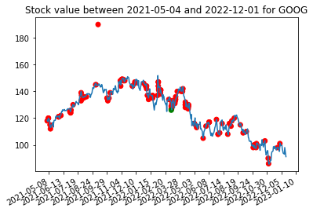

```python
"""
This method plots the curve of the given stock
values and superimposes trades on the locations and
prices they occured.
"""
def graph_stock_sales(df_no_OE, dates, df_stock):
  start_date = dates[0]
  end_date = dates[-1]
  plt.figure()
  plt.gca().xaxis.set_major_formatter(mdates.DateFormatter('%Y-%m-%d'))
  plt.gca().xaxis.set_major_locator(mdates.DayLocator(interval=36))
  plt.scatter(df_no_OE["TradeDate"], df_no_OE['AdjPrice'].apply(np.int64), color=df_no_OE['Color'])
  plt.plot(df_stock.index, df_stock['Open'])
  plt.title(label=f"Stock value between {start_date.date()} and {end_date.date()} for {ticker}")
  plt.gcf().autofmt_xdate()

graph_stock_sales(df_no_OE, dates, df_stock)
```

**Exploratory Data Analysis**

We can more formally test to see if the trades benefited the insider by looking at the general trend of the stock around 4 months after a sale of stock. The way I did it was by taking the date of trade finding the line of best fit for the next 4 months of stock data and seeing if the coefficient which is essentially the trend was negative in which case it was a good idea to sell, or if it was positive in which case it was a bad time to sell.

```python
"""
This method returns the coefficient of the
regression line between x and y
"""
def lin_reg(x, y):
  x =	np.array(x).reshape(-1, 1)
  y =	np.array(y).reshape(-1, 1)
  fit = LinearRegression().fit(x, y)
  return fit.coef_[0][0]

"""
This method arranges dates and opening
stock values to get their regression coefficient
"""
def get_st_perf(x):
  p = x['AdjPrice']
  d = x['TradeDate']
  s = d - relativedelta(days=+1)
  e = d + relativedelta(months=+4)
  valid_dates = list(filter(lambda x : s <= x and x <= e, df_stock.index))
  dates_in_range = df_stock.loc[valid_dates]
  coef = lin_reg([i for i in range(len(valid_dates))], list(dates_in_range['Open']))
  return coef
def get_dist_maxp(x):
  coef = get_st_perf(x)
  return coef
df_no_OE['distMaxProf'] = df_no_OE.apply(lambda x: get_dist_maxp(x), axis=1)
df_no_OE['ColorGains'] = df_no_OE.apply(lambda x: 'green' if (x['distMaxProf'] < 0 and x['Color'] == 'red')  or (x['distMaxProf'] > 0 and x['Color'] == 'green') else 'red', axis=1)
print(df_no_OE['distMaxProf'])
```

```
0     -0.546182
1     -0.346853
2      0.212188
3      0.190167
4      0.058970
         ...
285    0.357392
287    0.354492
296    0.348308
297    0.348308
299    0.341710
Name: distMaxProf, Length: 129, dtype: float64
```

**Exploratory Data Analysis**

I plotted the coefficients matched with each 'sale' trade and it shows that most were below 0. This indicates that many of the trades were well-timed and benefited the insider. Since there is only one instance of a purchase trade it wasn't very useful to look into so I focused on sale trades.

```
75.97% of the trades benefited the trader
```

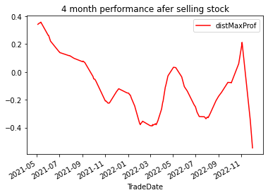

```python
df_sales = df_no_OE[df_no_OE['Color'] == 'red']
_ = df_sales.plot(x='TradeDate', y='distMaxProf', color='red', title = "4 month performance afer selling stock")
print(f"{100*round((len(df_no_OE[df_no_OE['distMaxProf'] < 0])/len(df_no_OE)), 4)}% of the trades benefited the trader")
```

**Exploratory Data Analysis**

I wanted to see if certain insiders had better results than others which was the case. The average trend for GOOG shares after Frances Arnold sold stock was -.4. Everyone did well however nobody had an average post-selloff coefficient above zero.

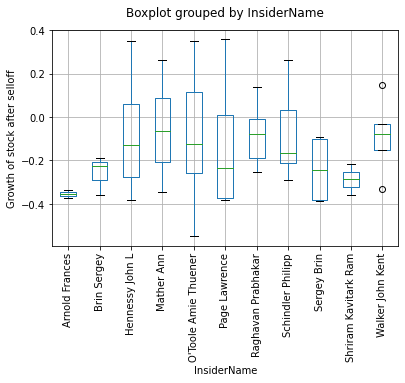

```python
df_groupedINDT_no_OE = df_no_OE.groupby(['InsiderName', 'TradeDate']).agg(
    Qty = ('Qty', 'max'),
    TradeType = ('TradeType', 'max'),
    TradeDate = ('TradeDate', 'max'),
    InsiderName = ('InsiderName', 'max'),
    distMaxProf = ('distMaxProf', 'max')
)
_ = df_groupedINDT_no_OE.reset_index(drop = True, inplace = True)
ax = df_groupedINDT_no_OE.boxplot(column=['distMaxProf'], by='InsiderName',rot=90)
_ = plt.title("")
_ = plt.ylabel("Growth of stock after selloff")
```

**Hypothesis Testing**

We can test the relationship between share sales and the coefficient of the trend line for the stock in the months after the trade using the quantity of stock sold. We can test to see if the indirect measure of confidence in the sale through quantity sold translates to a loose prediction of the performance.

The results show a negative correlation between the number of shares sold and the performance of the stock. However, the p-value for the correlation is very high so I have failed to reject the null hypothesis that the quantity of sold shares has an impact on the future performance of the stock.

```python
mod = smf.ols(formula='distMaxProf ~ AbsQty', data=df_sales)
res = mod.fit()
print(res.summary())
```

```
                            OLS Regression Results
==============================================================================
Dep. Variable:            distMaxProf   R-squared:                       0.005
Model:                            OLS   Adj. R-squared:                 -0.002
Method:                 Least Squares   F-statistic:                    0.6841
Date:                Sat, 17 Dec 2022   Prob (F-statistic):              0.410
Time:                        02:05:01   Log-Likelihood:                 20.695
No. Observations:                 128   AIC:                            -37.39
Df Residuals:                     126   BIC:                            -31.69
Df Model:                           1
Covariance Type:            nonrobust
==============================================================================
                 coef    std err          t      P>|t|      [0.025      0.975]
------------------------------------------------------------------------------
Intercept     -0.1255      0.021     -6.121      0.000      -0.166      -0.085
AbsQty     -1.746e-06   2.11e-06     -0.827      0.410   -5.92e-06    2.43e-06
==============================================================================
Omnibus:                        7.188   Durbin-Watson:                   0.106
Prob(Omnibus):                  0.027   Jarque-Bera (JB):                7.057
Skew:                           0.527   Prob(JB):                       0.0294
Kurtosis:                       2.540   Cond. No.                     1.09e+04
==============================================================================

Notes:
[1] Standard Errors assume that the covariance matrix of the errors is correctly specified.
[2] The condition number is large, 1.09e+04. This might indicate that there are
strong multicollinearity or other numerical problems.
```

**Exploratory Data Analysis**

I can compare the performance of insider traders at another large tech firm to see if there are any similarities. I chose Microsoft for the comparison and skipped some of the other exploratory graphs and looked to see how the insiders fared in their trades.

```python
ticker = "MSFT"
page = get_page(ticker)

headers, cells = get_cells(page)
df_msft = pd.DataFrame(cells)
df_msft.columns = headers

df_msft = format_df(df_msft)

msft = yf.Ticker(ticker)
splits = msft.splits
df_msft['AdjPrice'] = df_msft.apply(lambda x: float(x['Price'])/adj_split(x, splits), axis = 1)

df_msft_no_OE = df_msft.drop(df_msft[df_msft['Color'] == 'orange'].index)

dates = list(df_msft['TradeDate'])
dates.sort()

df_stock = get_df_stock(dates, ticker)
```

```
[*********************100%***********************]  1 of 1 completed
```

**Exploratory Data Analysis**

Looking at the large local peak it seems quite a few of the insiders traded around there and there was one purchase on the left foot of the peak. This indicates that some traders fared well. However, some traders sold near the bottom well before the peak which means they sold at a bad time. This suggests more volatile results for insider gains than for google which makes sense looking at the pattern of the stock value.

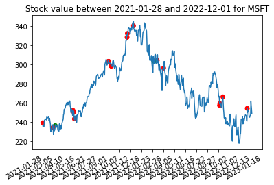

```python
graph_stock_sales(df_msft_no_OE, dates, df_stock)
```

```python
df_msft_no_OE['distMaxProf'] = df_msft_no_OE.apply(lambda x: get_dist_maxp(x), axis=1)
df_msft_no_OE['ColorGains'] = df_msft_no_OE.apply(lambda x: 'green' if (x['distMaxProf'] < 0 and x['Color'] == 'red')  or (x['distMaxProf'] > 0 and x['Color'] == 'green') else 'red', axis=1)
```

**Exploratory Data Analysis**

Looking at the bar charts, some insiders didn't do very well at all with them selling before a large shoot-up in the value of the stock and others in the opposit situation which solidifies my interpretation of the previous chart.

```
40.0% of the trades benefited the trader
```

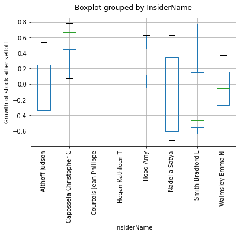

```python
print(f"{100*round((len(df_msft_no_OE[df_msft_no_OE['distMaxProf'] < 0])/len(df_msft_no_OE)), 4)}% of the trades benefited the trader")

df_msft_groupedINDT_no_OE = df_msft_no_OE.groupby(['InsiderName', 'TradeDate']).agg(
    Qty = ('Qty', 'max'),
    TradeType = ('TradeType', 'max'),
    TradeDate = ('TradeDate', 'max'),
    InsiderName = ('InsiderName', 'max'),
    distMaxProf = ('distMaxProf', 'max')
)
_ = df_msft_groupedINDT_no_OE.reset_index(drop = True, inplace = True)
ax = df_msft_groupedINDT_no_OE.boxplot(column=['distMaxProf'], by='InsiderName',rot=90)
_ = plt.title("")
_ = plt.ylabel("Growth of stock after selloff")
```

**Hypothesis Testing**

We can again test the relationship between volume of share sales and the coefficient of the future trend for MSFT.

```python
df_sales = df_msft_no_OE[df_msft_no_OE['Color'] == 'red']
mod = smf.ols(formula='distMaxProf ~ AbsQty', data=df_sales)
res = mod.fit()
print(res.summary())
```

```
                            OLS Regression Results
==============================================================================
Dep. Variable:            distMaxProf   R-squared:                       0.148
Model:                            OLS   Adj. R-squared:                  0.095
Method:                 Least Squares   F-statistic:                     2.778
Date:                Sat, 17 Dec 2022   Prob (F-statistic):              0.115
Time:                        02:05:02   Log-Likelihood:                -12.906
No. Observations:                  18   AIC:                             29.81
Df Residuals:                      16   BIC:                             31.59
Df Model:                           1
Covariance Type:            nonrobust
==============================================================================
                 coef    std err          t      P>|t|      [0.025      0.975]
------------------------------------------------------------------------------
Intercept      0.2485      0.137      1.814      0.088      -0.042       0.539
AbsQty     -1.078e-06   6.47e-07     -1.667      0.115   -2.45e-06    2.93e-07
==============================================================================
Omnibus:                        3.262   Durbin-Watson:                   0.710
Prob(Omnibus):                  0.196   Jarque-Bera (JB):                1.939
Skew:                          -0.573   Prob(JB):                        0.379
Kurtosis:                       1.873   Cond. No.                     2.34e+05
==============================================================================

Notes:
[1] Standard Errors assume that the covariance matrix of the errors is correctly specified.
[2] The condition number is large, 2.34e+05. This might indicate that there are
strong multicollinearity or other numerical problems.
```

**Conclusion**

Looking at the performance of stocks and the insider trades, insider trades don't seem to be a very good perdictor of wheather an insider trade will really tell you anything about the oncoming performance of the stock. For Google stock it appears to be fairly decent in terms of the perdicitve power but Microsoft is more volitile. This makes sense since insider traders could be trading for a number of reasons (financing charitable organizations, buying a home, emergency reserves, etc). Even the quantity traded might not be enough to indicate any fears an insider may have about their company's future as shown through OLS. There might be other ways to assess the perdictive power of insiders but underlying company performance will likely trump a murky trade.

```python
!cp drive/My*/Colab*/FinalProject.ipynb ./
```

```python
!jupyter nbconvert --to HTML "FinalProject.ipynb"
```

```
[NbConvertApp] Converting notebook FinalProject.ipynb to HTML
[NbConvertApp] Writing 577633 bytes to FinalProject.html
```